# Project 1 - Sushil Gupta

Sushil Gupta

11/16/2019

# Project 1 - JSON data for Greenhouse Gas Emissions Inventory

The Greenhouse Gas Emissions Inventory details the estimated New York State emissions releases from fuel combustion. The dataset includes a fuel type breakdown, by sector, for the current year. The data was obtained from [*this website*](https://catalog.data.gov/dataset/greenhouse-gas-emissions-from-fuel-combustion-by-fuel-type-million-metric-tons). .

## What is JSON data?

JSON stands for **JavaScript Object Notation** and it’s a data format. It is, simply, a way to hold bits of information, similar to a database.It is used primarily **to transmit data between a server and web application**, as an alternative to XML. JSON is a data format that consists of **name/value pairs** (AKA key/value pairs) in the form of strings. The name/value pairs are separated by a colon and each pair is separated by a comma. Features/Advantages of JSON:

- It is light-weight
- It is language independent
- Easy to read and write
- Text based, human readable data exchange format

For more information on JSON format, please go through the [wikipedia page](https://en.wikipedia.org/wiki/JSON). A good beginners tutorial on JSON can be [found here](https://www.w3schools.com/js/js_json_intro.asp).

## R Packages to read JSON data

The following packages are available.

- **rjson** - it seemed more like interacting with JSON object at object levels.
- **RJSONIO** - This is a package that allows conversion to and from data in Javascript object notation (JSON) format.I tried using it but couldnt make it to work.
- **jsonlite** - A fast JSON parser and generator optimized for statistical data and the web. Started out as a fork of ‘RJSONIO’, but has been completely rewritten in recent versions.I used this to read JSON data.

For more information on jsonlite package, refer to its [CRAN documentation](https://cran.r-project.org/web/packages/jsonlite/jsonlite.pdf).

## Read emissions data - jsonlite

```r
# READ JSON DATA
emi_json1 <- fromJSON("C:\\Users\\sugupt\\OneDrive - SAS\\00 sas sushil\\personal\\00_SushilGupta\\MasterStats_sg\\201908_ST_558_DataScienceForStatistician\\Project1\\emmission_rows.json", flatten=TRUE)

#EXTRACT DATA TABLE FROM JSON DATA
emi_json_data <- emi_json1$data

#ASSIGN COLUMN NAMES
colnames(emi_json_data)<-emi_json1$meta$view$columns$name

#TRANSFORM COLUMNS
emi_json_data_1 <- tbl_df(emi_json_data) %>% select("Year", "Fuel Type", "Transportation", "Electricity Generation", "Residential", "Commercial", "Industrial", "Total CO2 Emissions", "Percent of Total CO2 Emissions")
```

## Prepare emissions data

Now we will replace missing values to 0 in numeric data and also change the data types of these columns to numeric. Additonally, we will convert the categorical columns to factors.

```r
#CREATE A FUNCTION THAT WILL REPLACE N/A TO 0 AND ALSO CONVERT THAT COLUMN TO NUMERIC
rep_na_make_numeric <- function(col){
  emi_json_data_1[[col]][emi_json_data_1[[col]]=="N/A"] <- 0
  emi_json_data_1[[col]]<- as.numeric(emi_json_data_1[[col]])
  assign('emi_json_data_1',emi_json_data_1,envir=.GlobalEnv)
}

#CALL THIS FUNCTION FOR ALL NUMERIC VARIABLES
rep_na_make_numeric(col="Transportation")
rep_na_make_numeric(col="Electricity Generation")
rep_na_make_numeric(col="Residential")
rep_na_make_numeric(col="Commercial")
rep_na_make_numeric(col="Industrial")
rep_na_make_numeric(col="Total CO2 Emissions")
rep_na_make_numeric(col="Percent of Total CO2 Emissions")

#CATEGORICAL VARIABLES MUST BE CONVERTED TO FACTORS
emi_json_data_1$"Year"<- as.factor(emi_json_data_1$"Year")
emi_json_data_1$"Fuel Type"<- as.factor(emi_json_data_1$"Fuel Type")

#A LOOK AT THE DATA
kable(head(emi_json_data_1), caption = "Sample rows from Greenhouse Gas emissions data for NY")
```

Sample rows from Greenhouse Gas emissions data for NY

| Year | Fuel Type | Transportation | Electricity Generation | Residential | Commercial | Industrial | Total CO2 Emissions | Percent of Total CO2 Emissions |
| --- | --- | --- | --- | --- | --- | --- | --- | --- |
| 2016 | Jet Fuel | 10.19 | 0.00 | 0.00 | 0.00 | 0.00 | 10.19 | 6.1 |
| 2016 | Residual Oil | 2.34 | 0.29 | 0.00 | 0.15 | 0.22 | 3.00 | 1.8 |
| 2016 | Diesel Fuel (Distillate) | 12.57 | 0.00 | 0.00 | 0.00 | 0.00 | 12.57 | 7.6 |
| 2016 | Net Imports of Electricity | 0.00 | 3.80 | 0.00 | 0.00 | 0.00 | 3.80 | 2.3 |
| 2016 | Other Petroleum | 0.40 | 0.00 | 1.56 | 0.51 | 1.59 | 4.06 | 2.4 |
| 2016 | Heating Oil (Distillate) | 0.00 | 0.15 | 6.62 | 3.45 | 0.80 | 11.01 | 6.6 |

## Exploratory Data Analysis

CO2 emissions come from various sources like Transportation“,”Electricity Generation“,”Residential“,”Commercial“,”Industrial“,”Total CO2 Emissions“,”Percent of Total CO2 Emissions.

### 1. Contingency table

The following contingency table shows a list of these sources and years for which we have data.

```r
# DRAW CONTINGENCY TABLES
table(emi_json_data_1$`Fuel Type`, emi_json_data_1$Year)
```

```
##
##                              2010 2011 2012 2013 2014 2015 2016
##   Coal                          1    1    1    1    1    1    1
##   Diesel Fuel (Distillate)      1    1    1    1    1    1    1
##   Gasoline                      1    1    1    1    1    1    1
##   Heating Oil (Distillate)      1    1    1    1    1    1    1
##   Jet Fuel                      1    1    1    1    1    1    1
##   Natural Gas                   1    1    1    1    1    1    1
##   Net Imports of Electricity    1    1    1    1    1    1    1
##   Other Petroleum               1    1    1    1    1    1    1
##   Residual Oil                  1    1    1    1    1    1    1
```

This dataset has Co2 emissions from all these sources from year 2010 to 2016.

### 2. Box plots numeric summary

We want to see numeric summary for each of these sources. For this, we plot box plots.

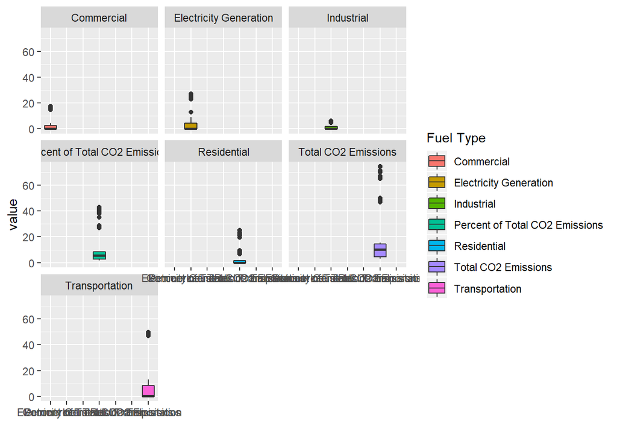

```r
# CONVER TO A VERTICAL FORMAT
emi_json_data_5<- emi_json_data_1 %>%
  gather(`Fuel Type`, value, "Transportation", "Electricity Generation", "Residential", "Commercial", "Industrial", "Total CO2 Emissions", "Percent of Total CO2 Emissions" )
# DRAW BOX PLOTS
emi_json_data_5 %>%
  ggplot(aes(x = `Fuel Type`, y = value, fill = `Fuel Type`))+
  geom_boxplot()+
  facet_wrap(~`Fuel Type`)+
  labs(x="")
```

### 3. Summary scatter plots

Now we want to see the total CO2 Emissions for each year for each fuel type or sources. We will draw a scatter plot.

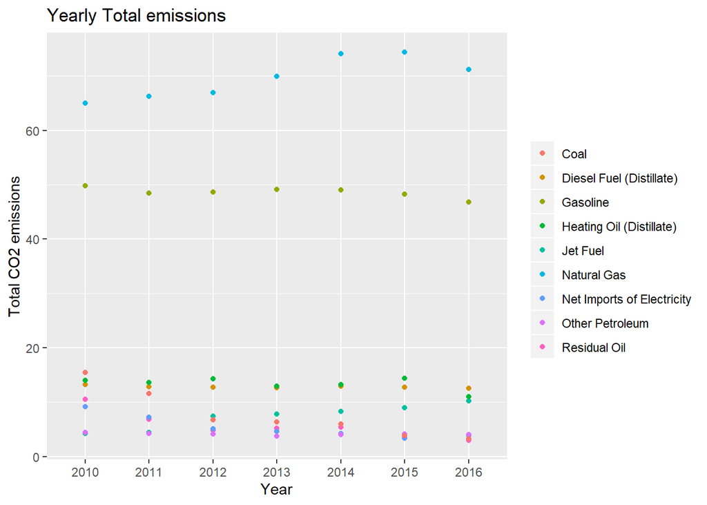

```r
#PLOTTING TOTAL CO2 EMISSIONS
g<- ggplot(data=emi_json_data_1, aes(x=Year, y=emi_json_data_1$`Total CO2 Emissions`, group=emi_json_data_1$`Fuel Type`))
g + geom_point(aes(color=emi_json_data_1$`Fuel Type`)) + labs(y="Total CO2 emissions", title="Yearly Total emissions") + theme(legend.title = element_blank())
```

### 4. Summary Scatter plots 2

We want to analyze the direct emissions from common population versus industrial causes. We create 2 new variables “total residential” that contains emissions from normal population (Transportation and Residential). The remaining sources are summed into total commerical. A scatter plot of this data is below.

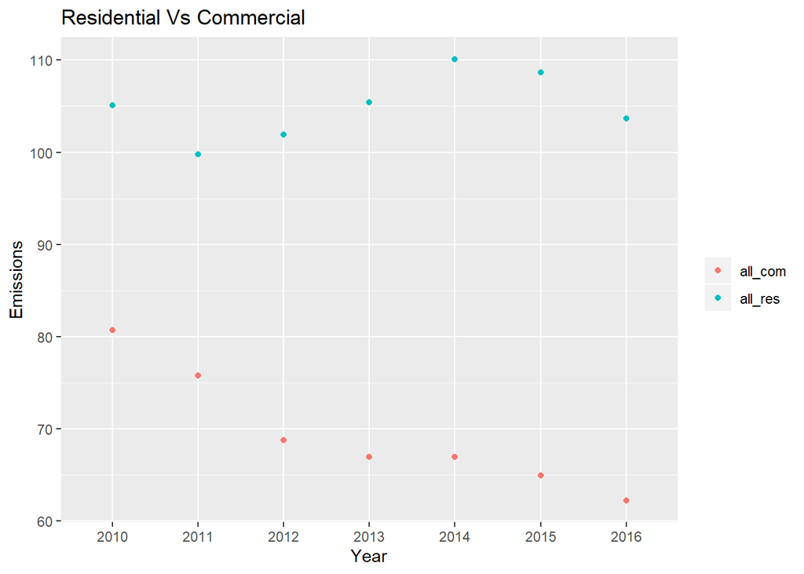

```r
# CREATE NEW VARIABLES FOR RESIDENTIAL VS COMMERCIAL
emi_json_data_2 <-
    mutate(emi_json_data_1, total_res = Transportation+Residential, total_com=`Electricity Generation`+Commercial+Industrial) %>%
    group_by(Year) %>%
    summarise(all_res=sum(total_res), all_com=sum(total_com))

# PLOT RESIDENTIAL AND COMMERCIAL TO COMPARE THEM
ggplot(emi_json_data_2, aes(x=Year, y = value, color = variable)) +
  geom_point(aes(y = all_res, col = "all_res")) +
  geom_point(aes(y = all_com, col = "all_com")) +
  labs(y="Emissions", title="Residential Vs Commercial") +
  theme(legend.title = element_blank())
```

This scatter plot clearly shows that the commercial emissions have reduced significantly over the years but residential emissions have been in the same range.

### 5. Bar plots

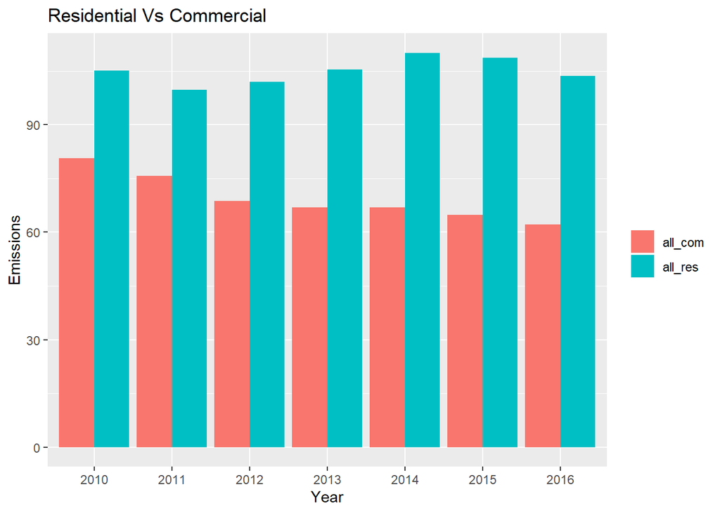

```r
#DO BAR PLOTS
emi_json_data_3 <- gather(emi_json_data_2, type, total, all_res:all_com)

plot <- ggplot(emi_json_data_3, aes(x=Year, total, fill=type))
plot <- plot + geom_bar(stat = "identity", position = 'dodge') + labs(y="Emissions", title="Residential Vs Commercial") +
  theme(legend.title = element_blank())
plot
```